# Regression

Class 3

R Workshop

2019-02-18

이번 시간에는 회귀분석을 간단히 소개합니다. 회귀분석은 실험 자료를 분석할 때 널리 활용되고 있으므로, 그 기본 개념을 잘 이해하는 것이 좋습니다.

## 사례 1: 연령과 목소리 높이

일단 간단한 사례와 함께 시작하겠습니다. 첫번째 사례는 Bodo Winter의 튜토리얼을 요약한 것입니다. 관심이 있는 학생은 그의 홈페이지 http://www.bodowinter.com에 있는 Tutorial 1과 2를 읽기 바랍니다.

여섯 명의 참가자를 모집하여 연령과 목소리 음높이를 측정하였습니다. 그 결과는 다음과 같았습니다.

```r
age <- c(14, 23, 35, 48, 52, 67)
pitch <- c(252, 244, 240, 233, 212, 204)
( d <- data.frame(age, pitch) )
```

```
##   age pitch
## 1  14   252
## 2  23   244
## 3  35   240
## 4  48   233
## 5  52   212
## 6  67   204
```

위 코드에서 data.frame 함수는 두 변수 age와 pitch를 합쳐서 SPSS, JASP 등 통계 소프트웨어가 선호하는 포맷을 만들어줍니다. 세 번째 코드를 ( )로 감쌌기 때문에 d의 값이 출력되었습니다. 어떤 패턴이 보이나요? 플롯을 그려봅시다.

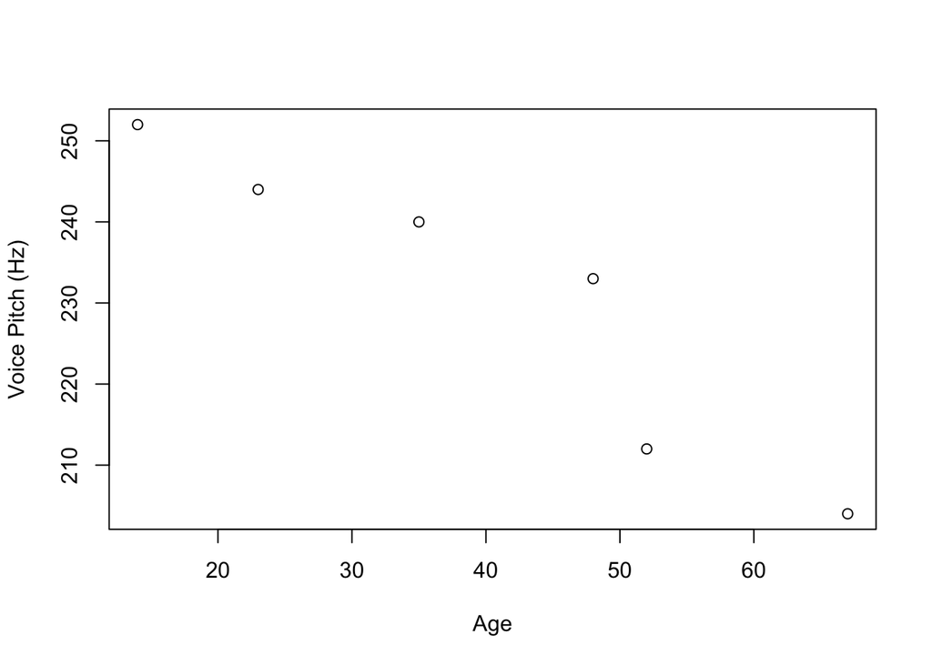

```r
plot(d$age, d$pitch, xlab="Age", ylab="Voice Pitch (Hz)")
```

나이가 들수록 목소리가 낮아지는 패턴이 보이네요. 이를 통계적으로 확인하려면 어떤 분석을 해야 할까요? 가장 쉬운 분석은 상관correlation을 계산하는 것입니다. 그러나 이번 사례에서는 회귀 분석을 실시하겠습니다. 상관에 비해, 회귀는 두 변인의 관계를 예측prediction하게 한다는 면에서 장점이 있습니다. 즉, 우리가 새로운 참가자를 모집한다면, 그 사람의 나이를 통해 목소리의 높낮이를 예측할 수 있게 됩니다. 어떻게 그것이 가능한지 살펴봅시다.

```r
m <- lm(pitch ~ age, data = d)
```

위 코드에서 lm 함수는 변수를 조합하여 자료에 가장 적합한 선형 모형linear model을 찾아줍니다. 선형 모형은 중고등학교에서 배우는 직선 함수 y = ax + b을 말합니다. 여기에서 y는 pitch, x는 age를 말합니다. lm 함수 안에 써넣은 *pitch ~ age*는 무엇이 x에 해당하고 y에 해당하는지를 의미합니다. lm 함수는 기울기 a와 절편 b를 계산한 모형을 만들어서 m에 저장합니다. 이제 모형 m의 내용을 summary 함수로 확인해봅시다.

```r
summary(m)
```

```
##
## Call:
## lm(formula = pitch ~ age, data = d)
##
## Residuals:
##      1      2      3      4      5      6
## -2.338 -2.149  4.769  9.597 -7.763 -2.115
##
## Coefficients:
##             Estimate Std. Error t value Pr(>|t|)
## (Intercept) 267.0765     6.8522   38.98 2.59e-06 ***
## age          -0.9099     0.1569   -5.80  0.00439 **
## ---
## Signif. codes:  0 '***' 0.001 '**' 0.01 '*' 0.05 '.' 0.1 ' ' 1
##
## Residual standard error: 6.886 on 4 degrees of freedom
## Multiple R-squared:  0.8937, Adjusted R-squared:  0.8672
## F-statistic: 33.64 on 1 and 4 DF,  p-value: 0.004395
```

출력값에는 모형의 공식, 잔차residuals, 계수coefficient, 및 여러 통계치가 포함되어 있습니다. 먼저 끝부분에 출력된 R-squared는 종속변인 pitch의 변량 중에서 독립변인 age가 설명할 수 있는 분량을 말합니다. 계수는 선형함수의 직선과 기울기에 관한 통계치를 보여주고 있습니다. 절편의 추정치 267은 나이가 0살인 참가자의 목소리 높이를 뜻합니다. 기울기의 추정치 -.9는 나이를 한 살(1 unit) 먹을 때마다 목소리가 0.9Hz 낮아진다는 것을 뜻합니다. 잔차는 선형 모형을 설명할 수 없었던 변량을 자료별로 보여줍니다. 이 결과들은 아래와 같이 그림으로 그렸을 때 더 분명합니다.

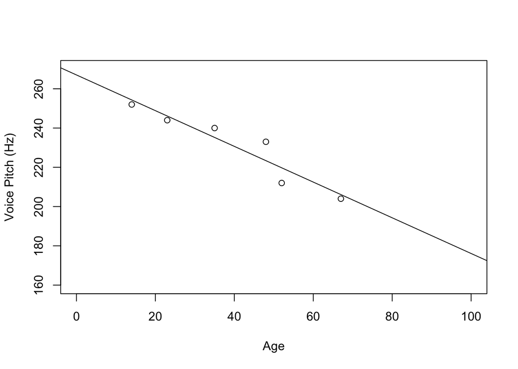

```r
plot(d$age, d$pitch, xlab="Age", ylab="Voice Pitch (Hz)",
     xlim=c(0,100), ylim=c(160, 270))
abline(m)
```

회귀 분석을 통해 이제 새로운 자료를 예측할 수 있게 되었습니다. 예를 들어, 100세인 할아버지의 목소리 높이는 어느 정도일까요?

## 사례 2: 기대수명

방금 분석했던 사례 1은 독립변인이 age 하나였기 때문에 simple regression이라고 합니다. 이제 독립변인이 여러 개인 경우를 생각해봅시다. 이러한 경우를 다중회귀multiple regression이라고 합니다. 이번 사례는 미국 50개 주에 관한 자료를 사용합니다. 이 자료는 R에 내장되어 있습니다.

```r
?state
```

이중에서 state.x77 자료를 사용합니다. 콘솔에 state.x77을 입력하여 내용물을 확인합시다. state.x77을 lm 함수로 분석하려면 data.frame으로 변환해야 합니다. 또한 변수 이름에서 빈칸을 제거해야 합니다.

```r
d <- as.data.frame(state.x77)
colnames(d)[4] <- "LifeExp"
colnames(d)[6] <- "HSGrad"
```

자료가 준비되었으니 다중회귀를 실시합시다. 분석의 목적은 소득, 문맹율, 살인율, 고등학교 졸업율이 기대수명을 예측하는 데 유용한 변인인지 확인하는 것입니다. 따라서 선형모형에서 y는 LifeExp가 되고, x는 Income, Illiteracy, Murder, HSGrad의 네 가지 항으로 구성됩니다. lm 함수는 각 x항의 기울기를 추정하게 됩니다. (편의상, 독립변인들 간의 상호작용은 없다고 가정합니다.)

```r
m <- lm(LifeExp ~ Income + Illiteracy + Murder + HSGrad, data=d)
summary(m)
```

```
##
## Call:
## lm(formula = LifeExp ~ Income + Illiteracy + Murder + HSGrad,
##     data = d)
##
## Residuals:
##      Min       1Q   Median       3Q      Max
## -1.56498 -0.53611  0.05303  0.58972  1.73972
##
## Coefficients:
##               Estimate Std. Error t value Pr(>|t|)
## (Intercept) 69.4833066  1.3253230  52.427  < 2e-16 ***
## Income       0.0001249  0.0002422   0.516   0.6084
## Illiteracy   0.2760771  0.3105081   0.889   0.3787
## Murder      -0.2619402  0.0444659  -5.891 4.53e-07 ***
## HSGrad       0.0461443  0.0218485   2.112   0.0403 *
## ---
## Signif. codes:  0 '***' 0.001 '**' 0.01 '*' 0.05 '.' 0.1 ' ' 1
##
## Residual standard error: 0.8049 on 45 degrees of freedom
## Multiple R-squared:  0.6698, Adjusted R-squared:  0.6405
## F-statistic: 22.82 on 4 and 45 DF,  p-value: 2.39e-10
```

출력값을 해석해보세요. 오늘은 여기까지 합시다.